# Solução do Desafio

Autor

Liana Petrarca

### 1. Preparação do Ambiente

```r
library(rio)
library(tidyverse)

# importar os 4 arquivos (tem que estar na pasta do projeto)
lab <- import("laboratorio.xlsx")
capsulas <- import("capsulas.xlsx")
graos <- import("graos.csv")
mmg <- import("mmg.xlsx")
```

### 2. Análise e Consolidação por Planta

```r
# GRAOS
# o numero da planta está no comeco do img, antes do primeiro "_"
# separar em duas colunas e descartar o resto
graos_planta <-
  graos |>
  separate(img, into = c("IMG", "resto"), sep = "_", extra = "merge") |>
  mutate(IMG = as.numeric(IMG)) |>
  group_by(IMG) |>
  summarise(NG = n(),
            CG = mean(length),
            LG = mean(width))
graos_planta
```

```
# A tibble: 418 × 4
     IMG    NG    CG    LG
   <dbl> <int> <dbl> <dbl>
 1     1   732 0.380 0.191
 2     2  1051 0.387 0.201
 3     3   530 0.402 0.203
 4     4   463 0.394 0.199
 5     5   748 0.383 0.194
 6     6  1140 0.382 0.202
 7     7   821 0.393 0.213
 8    11   772 0.378 0.192
 9    12  1227 0.376 0.194
10    13  1825 0.390 0.197
# ℹ 408 more rows
```

```r
# CAPSULAS
# cada linha é uma capsula, entao é só contar as linhas de cada planta
caps_planta <-
  capsulas |>
  separate(img, into = c("IMG", "resto"), sep = "_", extra = "merge") |>
  mutate(IMG = as.numeric(IMG)) |>
  group_by(IMG) |>
  summarise(NC = n())

caps_planta
```

```
# A tibble: 409 × 2
     IMG    NC
   <dbl> <int>
 1     2   155
 2     3    69
 3     5   107
 4     6   162
 5     7   120
 6    12   241
 7    13   240
 8    14   171
 9    15   244
10    16    53
# ℹ 399 more rows
```

```r
# JUNTAR com o laboratorio pela coluna IMG
planta <-
  lab |>
  left_join(graos_planta, by = "IMG") |>
  left_join(caps_planta, by = "IMG")
```

### 3. Análise e Consolidação por Genótipo

```r
# media de cada genotipo
# tem planta sem dado (NA), por isso o na.rm = TRUE
genotipo <-
  planta |>
  select(-IMG, -PLANTA) |>
  group_by(TIPO, GEN) |>
  summarise(across(where(is.numeric), \(x) mean(x, na.rm = TRUE)),
            .groups = "drop")

# mmg tem uma linha por genotipo, so preciso de TIPO, GEN e mmg
mmg_gen <-
  mmg |>
  select(TIPO, GEN, mmg) |>
  rename(MMG = mmg)

genotipo <-
  genotipo |>
  left_join(mmg_gen, by = c("TIPO", "GEN"))

genotipo
```

```
# A tibble: 120 × 12
   TIPO    GEN      AP    AC     NR     MC     MG    NG      CG      LG    NC
   <chr>   <chr> <dbl> <dbl>  <dbl>  <dbl>  <dbl> <dbl>   <dbl>   <dbl> <dbl>
 1 DOURADA G1     77.2  39.4   2.6    4.60   3.59  705.   0.389   0.198 110.
 2 DOURADA G108   93.8  56.8   3.4    2.77   2.08  464.   0.358   0.175  67.6
 3 DOURADA G133  NaN   NaN   NaN    NaN    NaN     NaN  NaN     NaN     NaN
 4 DOURADA G144  NaN   NaN   NaN    NaN    NaN     NaN  NaN     NaN     NaN
 5 DOURADA G145   96.4  56.2   4      4.67   3.53  787.   0.382   0.200 115.
 6 DOURADA G148   82.8  42.5   2.33   3.32   2.20  670    0.395   0.211 109.
 7 DOURADA G149  NaN   NaN   NaN    NaN    NaN     NaN  NaN     NaN     NaN
 8 DOURADA G150  NaN   NaN   NaN    NaN    NaN     NaN  NaN     NaN     NaN
 9 DOURADA G18    73.2  42     3.6    4.67   3.68  763.   0.360   0.181 104.
10 DOURADA G19    80.2  44.2   2.8    2.2    1.55  421.   0.407   0.210  63.8
# ℹ 110 more rows
# ℹ 1 more variable: MMG <dbl>
```

```r
# salvar a tabela final
export(genotipo, "dados_genotipo.xlsx")
```

### 4. Exploração e Visualização

#### Como a altura da planta se relaciona com o número de cápsulas?

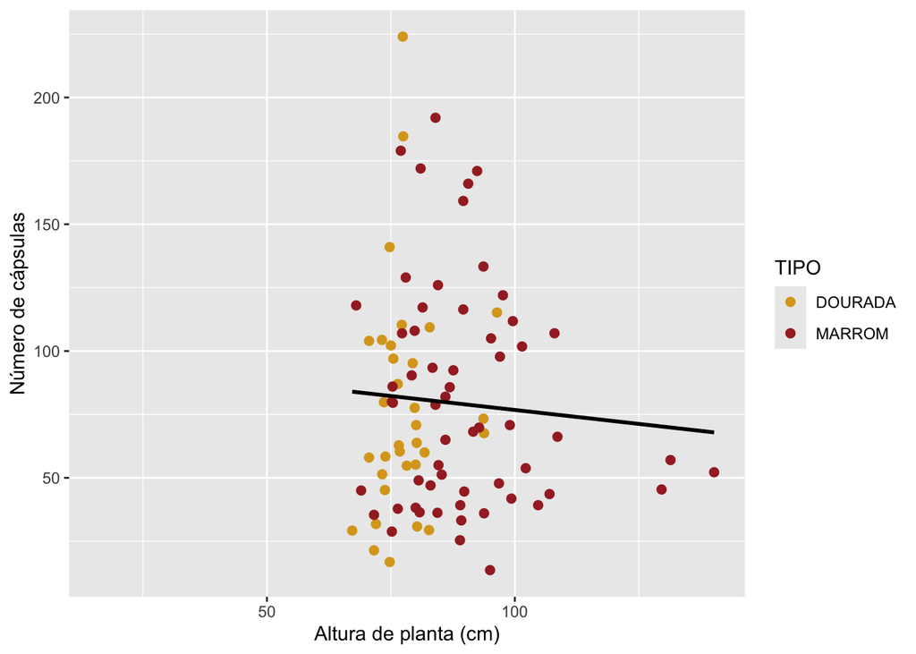

```r
ggplot(genotipo, aes(x = AP, y = NC)) +
  geom_point(aes(color = TIPO), size = 2) +
  geom_smooth(method = "lm", se = FALSE, color = "black") +
  scale_color_manual(values = c("goldenrod", "brown")) +
  labs(x = "Altura de planta (cm)",
       y = "Número de cápsulas")
```

```r
# correlacao
cor(genotipo$AP, genotipo$NC, use = "complete.obs")
```

```
[1] -0.0663049
```

#### Altura de planta: DOURADA x MARROM

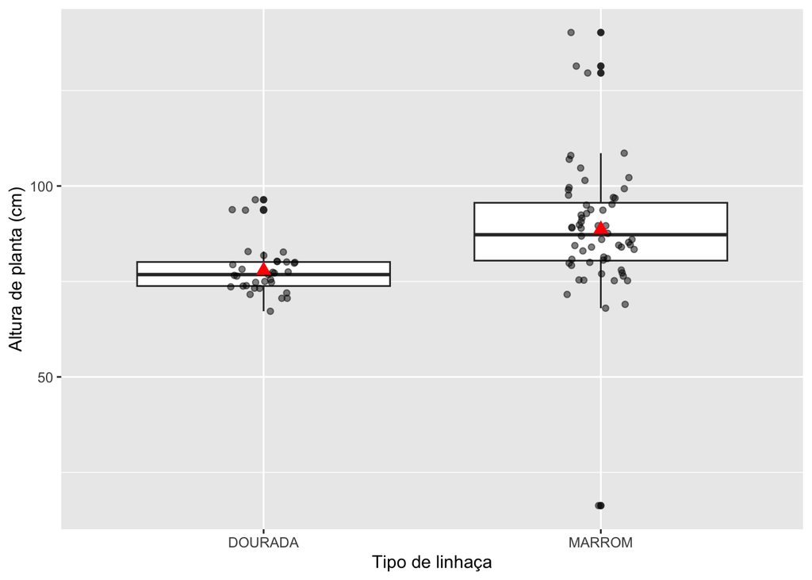

```r
ggplot(genotipo, aes(x = TIPO, y = AP)) +
  geom_boxplot() +
  geom_jitter(width = 0.1, alpha = 0.5) +
  stat_summary(fun = mean,
               geom = "point",
               shape = 17,
               size = 3,
               color = "red") +
  labs(x = "Tipo de linhaça",
       y = "Altura de planta (cm)")
```

```r
# media de altura de cada tipo
genotipo |>
  group_by(TIPO) |>
  summarise(AP_media = mean(AP, na.rm = TRUE),
            AP_dp = sd(AP, na.rm = TRUE))
```

```
# A tibble: 2 × 3
  TIPO    AP_media AP_dp
  <chr>      <dbl> <dbl>
1 DOURADA     77.9  6.53
2 MARROM      88.7 16.9
```

#### Quais os top 5 genótipos para produção de grãos (MG) de cada tipo de linhaça?

```r
top5 <-
  genotipo |>
  filter(!is.na(MG)) |>
  group_by(TIPO) |>
  slice_max(order_by = MG, n = 5) |>
  ungroup()

top5 |>
  select(TIPO, GEN, MG)
```

```
# A tibble: 10 × 3
   TIPO    GEN      MG
   <chr>   <chr> <dbl>
 1 DOURADA G5     5.28
 2 DOURADA G56    5.09
 3 DOURADA G23    3.89
 4 DOURADA G18    3.68
 5 DOURADA G1     3.59
 6 MARROM  G4     7.04
 7 MARROM  G2     6.32
 8 MARROM  G223   5.83
 9 MARROM  G63    5.01
10 MARROM  G12    4.94
```

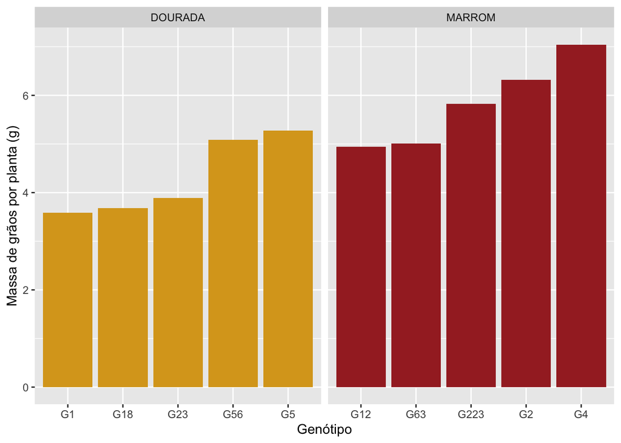

```r
ggplot(top5, aes(x = reorder(GEN, MG), y = MG, fill = TIPO)) +
  geom_col() +
  facet_wrap(~TIPO, scales = "free_x") +
  scale_fill_manual(values = c("goldenrod", "brown")) +
  labs(x = "Genótipo",
       y = "Massa de grãos por planta (g)") +
  theme(legend.position = "none")
```

#### Calcule o diferencial de seleção, ou seja, a diferença da média geral e a média dos top 5 genótipos, para cada tipo de linhaça, representando os valores em um gráfico de barras.

```r
# media geral de cada tipo
media_geral <-
  genotipo |>
  group_by(TIPO) |>
  summarise(geral = mean(MG, na.rm = TRUE))

# media dos 5 selecionados
media_top5 <-
  top5 |>
  group_by(TIPO) |>
  summarise(selecionados = mean(MG))

# DS = media dos selecionados - media geral
ds <-
  media_geral |>
  left_join(media_top5, by = "TIPO") |>
  mutate(DS = selecionados - geral,
         DS_porc = DS / geral * 100)

ds
```

```
# A tibble: 2 × 5
  TIPO    geral selecionados    DS DS_porc
  <chr>   <dbl>        <dbl> <dbl>   <dbl>
1 DOURADA  2.28         4.31  2.03    88.9
2 MARROM   2.20         5.83  3.62   164.
```

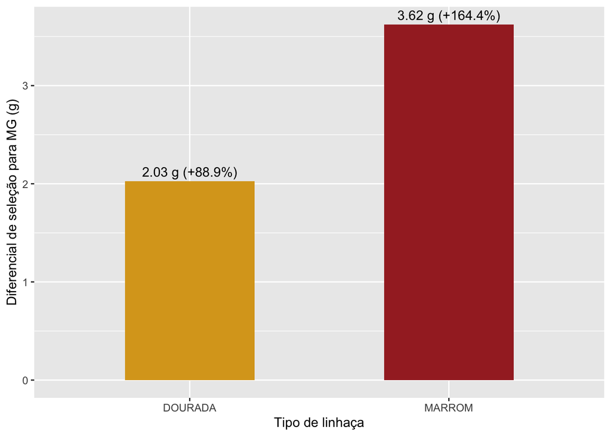

```r
ggplot(ds, aes(x = TIPO, y = DS, fill = TIPO)) +
  geom_col(width = 0.5) +
  geom_text(aes(label = paste0(round(DS, 2), " g (+", round(DS_porc, 1), "%)")),
            vjust = -0.5) +
  scale_fill_manual(values = c("goldenrod", "brown")) +
  labs(x = "Tipo de linhaça",
       y = "Diferencial de seleção para MG (g)") +
  theme(legend.position = "none")
```

## Conclusão

Juntando as quatro planilhas ficou uma tabela com 120 genótipos (incluindo as duas populações GPOP1 e GPOP2), mas 27 deles não têm dados de laboratório (NA). A altura de planta não mostrou relação com o número de cápsulas, a correlação ficou praticamente zero (r = -0,07), então plantas mais altas não necessariamente produzem mais cápsulas. Já entre os tipos teve diferença: os genótipos MARROM foram em média mais altos (88,7 cm contra 77,9 cm do que os genótipos do tipo DOURADA) e também bem mais variáveis. Para massa de grãos por planta (MG) os melhores do tipo DOURADA foram G5, G56, G23, G18 e G1, e os melhores MARROM foram G4, G2, G223, G63 e G12. As médias gerais dos dois tipos são parecidas (cerca de 2,2 a 2,3 g), mas o diferencial de seleção foi maior no tipo MARROM (3,62 g, +164%) do que no tipo DOURADA (2,03 g, +89%), indicando que existe mais variabilidade para selecionar dentro do tipo MARROM.